# Milestone Report - Text Prediction CapStone

Varun Poddar

3/16/2018

# Overview

This is the milestone report for the Data Science Capstone project. The goal is to build a predictive text application using natural language processing (NLP) techniques. I followed the coursera mentors’ discussion posts to delve into quanteda to analyze/summarize the datasets, and build a predictive text model. Off the languages provided, the work focuses on data in English language only.

## Data Setup

The relevant dataset was downloaded and unzipped. Thereafter, read all 3 English language files, subsetting 10,000 records from each to analyze, explore and clean the underlying data. For easy reference in the future and to save computational resources, this data subset was saved to a file subsetData.txt.

```r
pkgs = c("data.table", "quanteda", "tm", "knitr", "stringi")
lapply(pkgs, require, character.only=TRUE)
```

```
## [[1]]
## [1] TRUE
##
## [[2]]
## [1] TRUE
##
## [[3]]
## [1] TRUE
##
## [[4]]
## [1] TRUE
##
## [[5]]
## [1] TRUE
```

```r
rm(pkgs)

fileURL <- "https://d396qusza40orc.cloudfront.net/dsscapstone/dataset/Coursera-SwiftKey.zip"
if(!file.exists("dataset.zip")) {
    download.file(url=fileURL, destfile = "dataset.zip", method="curl")
    unzip("dataset.zip")
}
rm(fileURL)

#read all 3 files
blogs <- readLines("./final/en_US/en_US.blogs.txt", encoding = "UTF-8", skipNul=TRUE)
news <- readLines("./final/en_US/en_US.news.txt", encoding = "UTF-8", skipNul=TRUE)
twitter <- readLines("./final/en_US/en_US.twitter.txt", encoding = "UTF-8", skipNul=TRUE)

set.seed(1234)
if(!file.exists("subsetData.txt")) {
    #subset 10k lines from each file and write to a text file named subsetData
    subsetData <- c(sample(twitter,10000),
                    sample(news,10000),
                    sample(blogs,10000)
                    )
    writeLines(subsetData, "./subsetData.txt")
}
```

## Data Summary

The following summary statistics can be observed about the three files:

```r
sizes <- round(file.info(c("./final/en_US/en_US.blogs.txt","./final/en_US/en_US.news.txt","./final/en_US/en_US.twitter.txt"))$size/1024^2)

lines <- sapply(list(blogs,news,twitter), length)

## Words per file
words <- c(sum(stri_count_words(blogs)),
           sum(stri_count_words(news)),
           sum(stri_count_words(twitter))
           )

## Words per line
wordsLine <- c(mean(stri_count_words(blogs)),
               mean(stri_count_words(news)),
               mean(stri_count_words(twitter))
               )

summaryFiles <- data.frame(file = c("blogs", "news", "twitter"),
                           size = sizes,
                           lines = lines,
                           words = words,
                           words_per_line = wordsLine
                     )

kable(summaryFiles)
```

| file | size | lines | words | words_per_line |
| --- | --- | --- | --- | --- |
| blogs | 200 | 899288 | 37546246 | 41.75108 |
| news | 196 | 1010242 | 34762395 | 34.40997 |
| twitter | 159 | 2360148 | 30093410 | 12.75065 |

```r
rm(blogs, news, twitter)
```

## Data Cleanup and Transformation

```r
#reload subsetData
subsetData <- readLines("./subsetData.txt", encoding = "UTF-8")

#tokenization and n-grams using quanteda
subsetCorpus <- corpus(subsetData)

#create function to create dfm objects when calling n-grams
createDfm <- function(obj, n) {
        nGramSp <- dfm(obj, ngrams= n, tolower = TRUE, remove_numbers=TRUE, remove_punct=TRUE, remove_symbols=TRUE, remove_separators=TRUE, remove_hyphens=TRUE, remove_url=TRUE, remove_twitter=TRUE, remove=stopwords("english"))
}

#call function to create dfm objects containing n-grams with a minimum frequency of 25
uniGram <- dfm_trim(createDfm(subsetCorpus, 1), min_count=25)
biGram <- dfm_trim(createDfm(subsetCorpus, 2), min_count=25)
triGram <- dfm_trim(createDfm(subsetCorpus, 3), min_count=25)
quadGram <- dfm_trim(createDfm(subsetCorpus, 4), min_count=25)
```

```r
#get summary of number of features in each n-gram dataset
summaryFeatures <- data.frame(
                Dataset = c("uniGrams", "biGrams", "triGrams", "quadGrams"),
                Number_Features = c(nfeat(uniGram), nfeat(biGram), nfeat(triGram), nfeat(quadGram))
                   )

kable(summaryFeatures)
```

| Dataset | Number_Features |
| --- | --- |
| uniGrams | 3291 |
| biGrams | 2698 |
| triGrams | 363 |
| quadGrams | 21 |

## Exploring Graphically

The quanteda methods are also great at selecting the top frequency features across each n-gram dataset, and creating various graphs to explore the data visually. I used the wordcloud and network plot methods to see the features for uni/bi/tri/quad-grams.

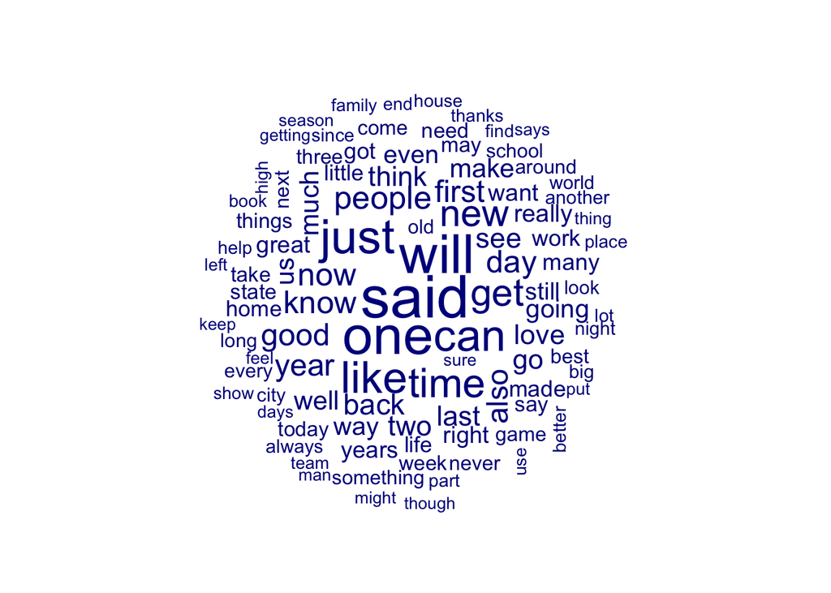

```r
#show the top-20 features in each n-gram dataset and highlight most common words in a wordcloud
textplot_wordcloud(uniGram, max_words = 100, min_size=0.5, max_size=3.0)
```

```r
topfeatures(uniGram, 20)
```

```
##   said    one   will   just    can   like   time    get    new people
##   2981   2676   2669   2281   2099   2078   1879   1716   1693   1366
##    now   know    day  first   good   year   also   back    see    two
##   1337   1308   1296   1275   1270   1267   1214   1171   1117   1111
```

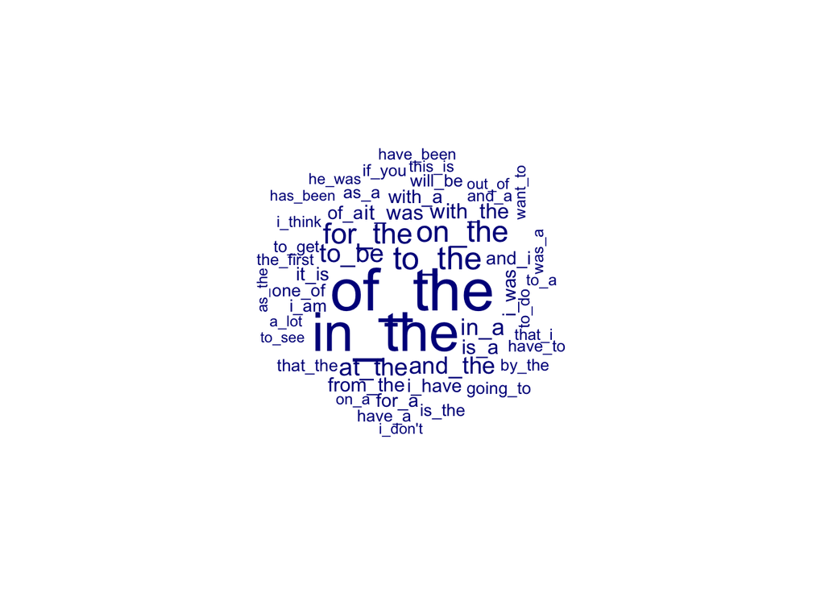

```r
textplot_wordcloud(biGram, max_words = 50, min_size=0.5, max_size=3.0)
```

```r
topfeatures(biGram, 20)
```

```
##   of_the   in_the   to_the   on_the  for_the    to_be   at_the  and_the
##     4264     3853     1932     1778     1665     1394     1304     1230
##     in_a with_the   it_was     is_a from_the   with_a    it_is   i_have
##     1165      997      958      913      844      784      783      771
##    for_a    i_was    and_i     of_a
##      765      758      755      744
```

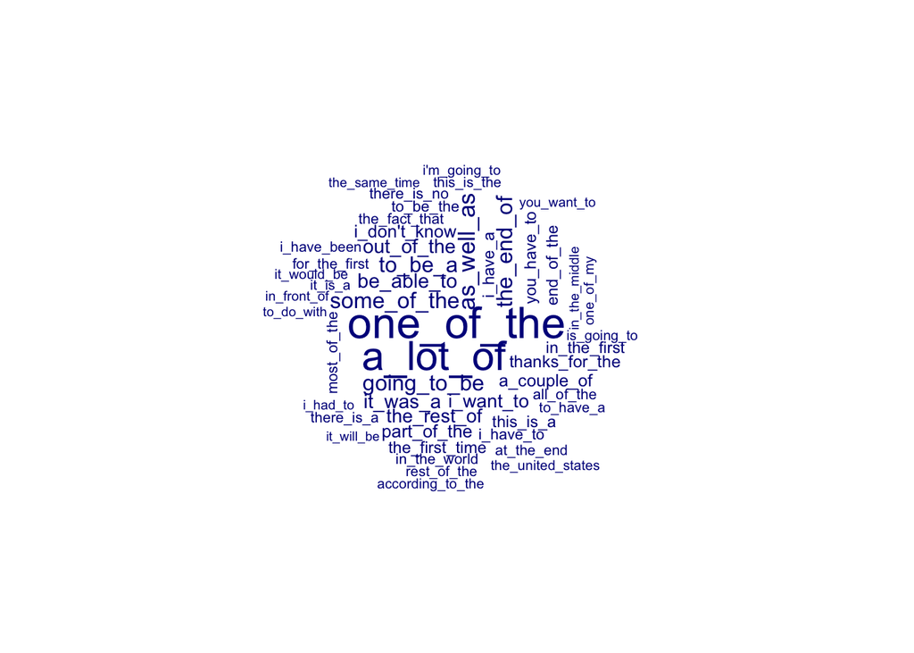

```r
textplot_wordcloud(triGram, max_words = 50, min_size=0.25, max_size=2.0)
```

```r
topfeatures(triGram, 20)
```

```
##     one_of_the       a_lot_of     as_well_as    some_of_the     the_end_of
##            331            304            159            148            146
##    going_to_be        to_be_a     be_able_to       it_was_a     out_of_the
##            145            143            128            124            124
##    the_rest_of      i_want_to    part_of_the   i_don't_know    a_couple_of
##            119            117            109            106            102
## thanks_for_the the_first_time       i_have_a    you_have_to      this_is_a
##             99             95             94             94             94
```

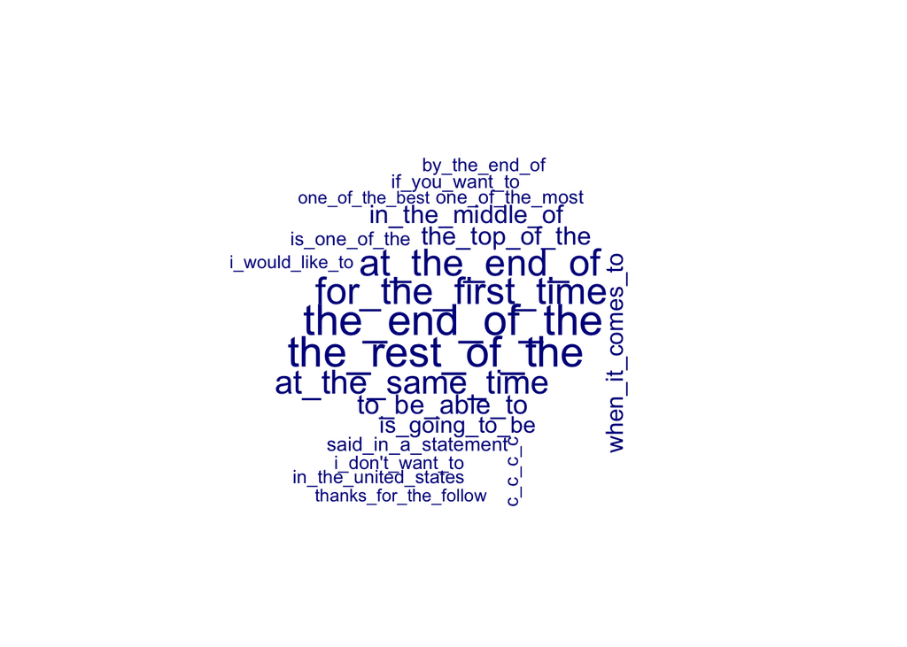

```r
textplot_wordcloud(quadGram, max_words = 50, min_size=0.25, max_size=2.0)
```

```r
topfeatures(quadGram, 20)
```

```
##       the_end_of_the      the_rest_of_the   for_the_first_time
##                   77                   76                   66
##        at_the_end_of     at_the_same_time        to_be_able_to
##                   66                   57                   44
##       the_top_of_the     in_the_middle_of     when_it_comes_to
##                   41                   41                   38
##       is_going_to_be  said_in_a_statement      one_of_the_most
##                   36                   29                   28
##        is_one_of_the       if_you_want_to              c_c_c_c
##                   28                   28                   28
##      i_don't_want_to        by_the_end_of in_the_united_states
##                   27                   27                   27
##      i_would_like_to      one_of_the_best
##                   26                   25
```

Alternatively, I also explored network-type relationships between most frequent features using FCM for unigrams and bigrams since they are more likely to appear together. Higher degree grams are not as likely to occur simultaneously. As FYI, a feature-ouccerances matrix (FCM) records number of co-occurances of tokens.

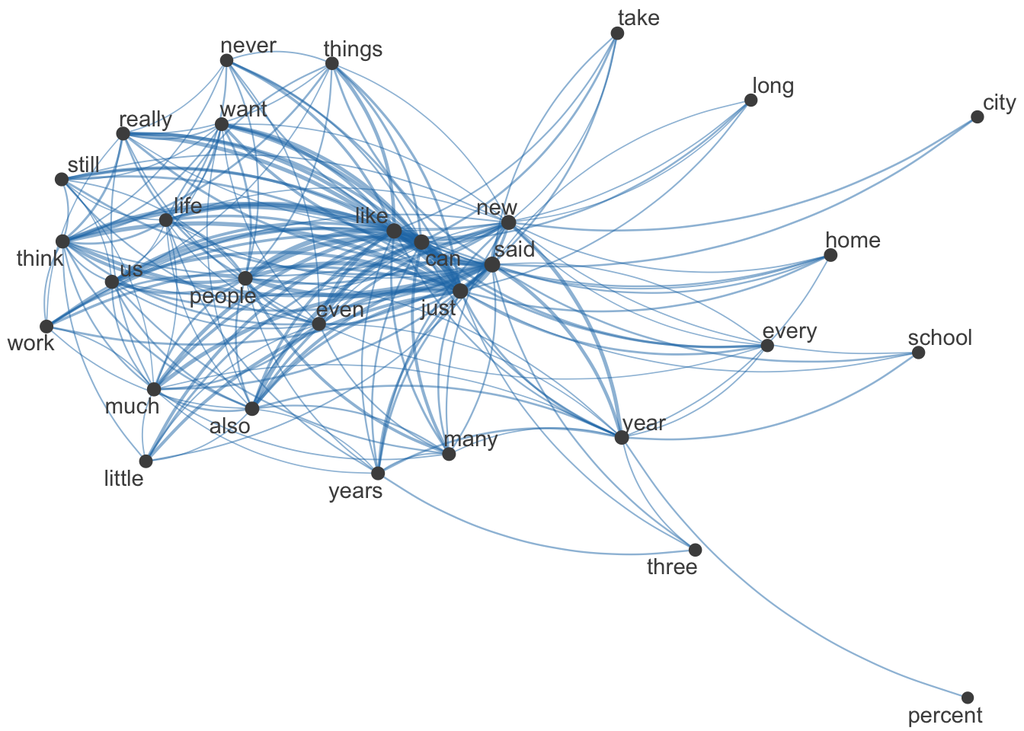

```r
uni_fcm <- fcm(uniGram)
feat <- names(topfeatures(uni_fcm, 50))
uni_fcm <- fcm_select(uni_fcm, feat)
#dim(uni_fcm)
size <- log(colSums(dfm_select(uniGram, feat)))
textplot_network(uni_fcm, min_freq = 0.8, vertex_size = size / max(size) * 3)
```

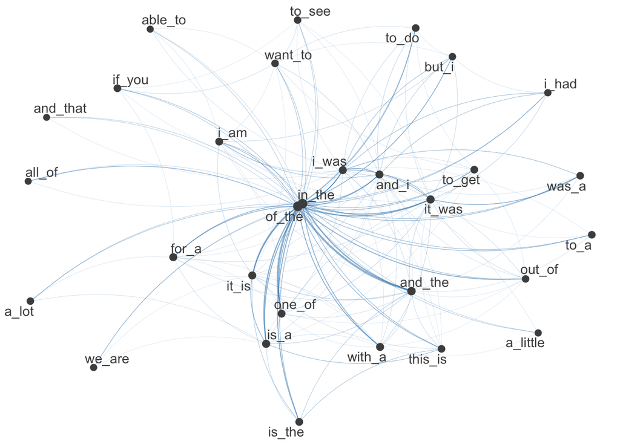

```r
bi_fcm <- fcm(biGram)
feat <- names(topfeatures(bi_fcm, 50))
bi_fcm <- fcm_select(bi_fcm, feat)
#dim(bi_fcm)
size <- log(colSums(dfm_select(biGram, feat)))
textplot_network(bi_fcm, min_freq = 0.8, vertex_size = size / max(size) * 3)
```

## Next Steps

Next steps include focusing on the predictive model and shiny application. There are minor tweaks that I may make to improve the efficacy of the n-gram datasets. My assumption is that the saved n-gram datasets will make downstream modeling activities much more efficient. For example, at this juncture I limited the dataset to 10,000 records from each of the three files, and a frequency threshold to improve computational speed. Depending on the accuracy of my predictions, I may have to revisit those thresholds.